# Project 3: Effect of swarms’ boundary value on computation

Here we observe the effects of swarms’ boundary value on computation.

```bash
#!/bin/bash

# v0.1.0
# 29.10.2019
# This script uses a fasta-file to measure computation time and memory of swarm
# used with different boundary values and creates a .stats file for each boundary value.



FASTA_FILE="${1}"
SUBFOLDER="Test_stats"
FILE_NAME="${FASTA_FILE/.*/}"
mkdir -p "${SUBFOLDER}"
STATS="${SUBFOLDER}/${FILE_NAME}_b"


awk -F "_" '/^>/ {a=$2 - 1 ; if (a > 0) {print a}}' ${FASTA_FILE} | \
tac | \
while read b ; do
    for i in {1..3} ; do # repeat it 3 times
        echo -ne "${FILE_NAME}\t${i}\t${b}\t" # shows boundary values as column next to other values
        /usr/bin/time -f "%e\t%M\t%P" \
        swarm -f -b "${b}" \
            "${FASTA_FILE}" \
            -s ${STATS}_${b}.stats \
            -o /dev/null \
            -l /dev/null 2>&1
    done
paste - - < tmp.log >  TARA_V9_264_samples.log

exit 0
```

[output not shown]

##We create a .log-table looking like this for each sample:

Sample Iteration boundary-value Time(s) Memory(GB) CPU(%) Number_of_Clusters neotropical_soils_18S_V4_175_samples_21_percent 1 1 23.64 1046560 643% 1109687 neotropical_soils_18S_V4_175_samples_21_percent 2 1 22.05 1046520 657% 1109687 neotropical_soils_18S_V4_175_samples_21_percent 3 1 22.43 1046516 655% 1109687 neotropical_soils_18S_V4_175_samples_21_percent 1 2 149.19 6435656 1318% 541076 neotropical_soils_18S_V4_175_samples_21_percent 2 2 134.20 6435820 1353% 541076 neotropical_soils_18S_V4_175_samples_21_percent 3 2 135.74 6435744 1374% 541076

##Then we use these files to create a plot that shows the different computation values changing while increasing the boundary value:

```r
library(tidyverse)
library(scales)

setwd("C:\\Users\\Milena K\\OneDrive\\Documents\\Master_Biostudium\\Projekt_France")
```

[output not shown]

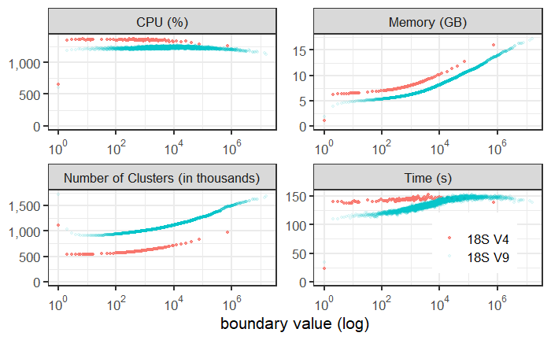

```r
input_18SV9 <- "TARA_V9_264_samples.log"
input_18SV4 <- "neotropical_soils_18S_V4_175_samples_21_percent.log"
output <- "18S_V4_and_V9_fastidious_computation_parameters.pdf"
col_names <- c("Sample", "Iteration", "boundary_value", "Time (s)",
               "Memory (GB)", "CPU", "Number of Clusters (in thousands)")

## synopsys:
## - merge V4 and V9 datasets,
## - average iteration (group by boundary value),
## - remove legend,
## - convert memory into gigabytes,
## - convert number of clusters into kilos,
## - compute mean per iteration,
## - remove y-axis label,
## - use comma for the y-axis,
## - give different alpha-values

bind_rows(read_tsv(input_18SV4, col_names = col_names) %>%
            mutate(marker = "18S V4"),
          read_tsv(input_18SV9, col_names = col_names) %>%
            mutate(marker = "18S V9")) %>%
  mutate(`CPU (%)` = parse_number(CPU)) %>%
  select (-CPU) %>%
  gather("variables", "values", c(`Time (s)`, `Memory (GB)`,
                                  `CPU (%)`, `Number of Clusters (in thousands)`)) %>%
  mutate(values = case_when (variables == "Memory (GB)" ~ values / 2^20,
                             variables == "Number of Clusters (in thousands)" ~ values / 1000,
                             TRUE ~ values)) %>%
  group_by(marker, boundary_value, variables) %>%
  mutate(values = mean(values)) %>%
  ungroup() %>%
  select(-Iteration) %>%
  unique() ->  d
ggplot(data = d, aes(x = boundary_value, y = values, colour = marker, alpha = marker)) +
  geom_point(size = 1.0) +
  expand_limits(y = 0) +
  theme_bw(base_size = 16) +
  scale_alpha_manual(values = c(0.8, 0.08)) +
  scale_x_log10(name = "boundary value (log)",
                breaks = trans_breaks("log10", function(x) 10^x),
                labels = trans_format("log10", math_format(10^.x))) +
  scale_y_continuous(labels = comma) +
  labs(x = "boundary value") +
  theme(axis.title.y = element_blank(),
        legend.title = element_blank(),
        legend.justification = c(1, 0),
        legend.position = c(0.95, 0.05)) +
  facet_wrap(~ variables, scales = "free")
```

```r
#ggsave(output, width = 16, height = 9)
```

In general you can see that the lowest time, memory and CPU values and the highest number of cluster value are bound with the lowest boundary value (1 = no fastidious option) in both datasets, whereas only the max memory value is bound to the max boundary value (724731 V4; 15638315 V9) in both datasets. The highest peaks in time and CPU and the lowest number of clusters are not bound with the max boundary value, but rather rise to a certain level and then fall again. Also interesting could be the values where the boundary value (bv) is equal 2: in comparison to bv == 1, bv == 2 needs at least three times longer, the CPU is doubled, there is at least three times more memory needed and the number of clusters are cut down to a half. The max time is 154.27 on 3866 boundary value (V4) and 158.39 on 89624 boundary value (V9). The max CPU is 1381% on 1252 boundary value (V4) and 1281% on 13031 boundary value (V9). The min Number of Clusters is 533961 on 3 boundary value (V4) and 906547 on 11 boundary value (V9).

```r
log_18SV9 <- read_tsv("TARA_V9_264_samples.log", col_names = col_names)
log_18SV4 <- read_tsv("neotropical_soils_18S_V4_175_samples_21_percent.log", col_names = col_names)
```

##Find the means of the three Iterations:

```r
colnames <- c("boundary_value", "time", "memory", "CPU", "number_clusters")
log_18SV9_mean <- as.data.frame(cbind(colMeans(matrix(log_18SV9$boundary_value, nrow=3)),
                                    colMeans(matrix(log_18SV9$`Time (s)`, nrow=3)),
                                    colMeans(matrix(log_18SV9$`Memory (GB)`, nrow=3)),
                                    colMeans(matrix(parse_number(log_18SV9$CPU), nrow=3)),
                                    colMeans(matrix(log_18SV9$`Number of Clusters (in thousands)`, nrow=3))))
colnames(log_18SV9_mean) <- colnames

log_18SV4_mean <- as.data.frame(cbind(colMeans(matrix(log_18SV4$boundary_value, nrow=3)),
                                    colMeans(matrix(log_18SV4$`Time (s)`, nrow=3)),
                                    colMeans(matrix(log_18SV4$`Memory (GB)`, nrow=3)),
                                    colMeans(matrix(parse_number(log_18SV4$CPU), nrow=3)),
                                    colMeans(matrix(log_18SV4$`Number of Clusters (in thousands)`, nrow=3))))
colnames(log_18SV4_mean) <- colnames
```

Find max and mins from the mean of the iterations:

```r
values_mean <- as.data.frame(rbind(log_18SV4_mean[which.max(log_18SV4_mean[,2]), ],
                                   log_18SV4_mean[which.max(log_18SV4_mean[,3]), ],
                                   log_18SV4_mean[which.max(log_18SV4_mean[,4]), ],
                                   log_18SV4_mean[which.max(log_18SV4_mean[,5]), ],
                                   log_18SV4_mean[which.max(log_18SV4_mean[,1]), ],
                                   log_18SV4_mean[which.min(log_18SV4_mean[,2]), ],
                                   log_18SV4_mean[which.min(log_18SV4_mean[,3]), ],
                                   log_18SV4_mean[which.min(log_18SV4_mean[,4]), ],
                                   log_18SV4_mean[which.min(log_18SV4_mean[,5]), ],
                                   log_18SV4_mean[which.min(log_18SV4_mean[,1]), ],
                                   log_18SV9_mean[which.max(log_18SV9_mean[,2]), ],
                                   log_18SV9_mean[which.max(log_18SV9_mean[,3]), ],
                                   log_18SV9_mean[which.max(log_18SV9_mean[,4]), ],
                                   log_18SV9_mean[which.max(log_18SV9_mean[,5]), ],
                                   log_18SV9_mean[which.max(log_18SV9_mean[,1]), ],
                                   log_18SV9_mean[which.min(log_18SV9_mean[,2]), ],
                                   log_18SV9_mean[which.min(log_18SV9_mean[,3]), ],
                                   log_18SV9_mean[which.min(log_18SV9_mean[,4]), ],
                                   log_18SV9_mean[which.min(log_18SV9_mean[,5]), ],
                                   log_18SV9_mean[which.min(log_18SV9_mean[,1]), ]))

#values_mean<-as.data.frame(values_mean)

values_mean$column <- c("Time_max", "Memory_max", "CPU_max", "Number of Clusters_max",
                        "Boundary Value_max", "Time_min", "Memory_min", "CPU_min",
                        "Number of Clusters_min", "Boundary Value_min")

values_mean$samples <- c(rep("18S_V4", 10), rep("18S_V9", 10))
```

Find the values of the boundary value 2 concerning the mean of the iterations

```r
boundary_value_2_mean <- rbind(log_18SV4_mean[which.min(log_18SV4_mean$boundary_value), ],
                               log_18SV9_mean[which.min(log_18SV9_mean$boundary_value), ],
                               log_18SV4_mean[which(log_18SV4_mean$boundary_value == 2), ],
                               log_18SV9_mean[which(log_18SV9_mean$boundary_value == 2), ])

boundary_value_2_mean$Sample <- c("18S_V4", "18S_V9", "18S_V4", "18S_V9")
```

(Find max and mins of all iterations

```r
values <- rbind(log_18SV4[which.max(log_18SV4$`Time (s)`), ],
log_18SV4[which.max(log_18SV4$`Memory (GB)`), ],
log_18SV4[which.max(parse_number(log_18SV4$CPU)), ],
log_18SV4[which.max(log_18SV4$`Number of Clusters (in thousands)`), ],
log_18SV4[which.max(log_18SV4$boundary_value), ],
log_18SV4[which.min(log_18SV4$`Time (s)`), ],
log_18SV4[which.min(log_18SV4$`Memory (GB)`), ],
log_18SV4[which.min(parse_number(log_18SV4$CPU)), ],
log_18SV4[which.min(log_18SV4$`Number of Clusters (in thousands)`), ],
log_18SV4[which.min(log_18SV4$boundary_value), ],
log_18SV9[which.max(log_18SV9$`Time (s)`), ],
log_18SV9[which.max(log_18SV9$`Memory (GB)`), ],
log_18SV9[which.max(parse_number(log_18SV9$CPU)), ],
log_18SV9[which.max(log_18SV9$`Number of Clusters (in thousands)`), ],
log_18SV9[which.max(log_18SV9$boundary_value), ],
log_18SV9[which.min(log_18SV9$`Time (s)`), ],
log_18SV9[which.min(log_18SV9$`Memory (GB)`), ],
log_18SV9[which.min(parse_number(log_18SV9$CPU)), ],
log_18SV9[which.min(log_18SV9$`Number of Clusters (in thousands)`), ],
log_18SV9[which.min(log_18SV9$boundary_value), ]
)

values$Column <- c("Time_max", "Memory_max", "CPU_max", "Number of Clusters_max", "Boundary Value_max", "Time_min", "Memory_min", "CPU_min", "Number of Clusters_min", "Boundary Value_min")
values <- values[,c(1,8,2,4,3,5,6,7)]
values
```

| Sample | Column | Iteration | Time (s) | boundary_value | Memory (GB) | CPU | Number of Clusters (in thousands) |
| --- | --- | --- | --- | --- | --- | --- | --- |
| neotropical_soils_18S_V4_175_samples_21_percent | Time_max | 3 | 154.27 | 3866 | 9614644 | 1339% | 668328 |
| neotropical_soils_18S_V4_175_samples_21_percent | Memory_max | 2 | 140.09 | 724731 | 16821592 | 1256% | 977094 |
| neotropical_soils_18S_V4_175_samples_21_percent | CPU_max | 1 | 148.41 | 1252 | 8565604 | 1381% | 627239 |
| neotropical_soils_18S_V4_175_samples_21_percent | Number of Clusters_max | 1 | 23.64 | 1 | 1046560 | 643% | 1109687 |
| neotropical_soils_18S_V4_175_samples_21_percent | Boundary Value_max | 1 | 139.69 | 724731 | 16821504 | 1242% | 977094 |
| neotropical_soils_18S_V4_175_samples_21_percent | Time_min | 2 | 22.05 | 1 | 1046520 | 657% | 1109687 |
| neotropical_soils_18S_V4_175_samples_21_percent | Memory_min | 3 | 22.43 | 1 | 1046516 | 655% | 1109687 |
| neotropical_soils_18S_V4_175_samples_21_percent | CPU_min | 1 | 23.64 | 1 | 1046560 | 643% | 1109687 |
| neotropical_soils_18S_V4_175_samples_21_percent | Number of Clusters_min | 1 | 140.38 | 3 | 6588636 | 1359% | 533961 |
| neotropical_soils_18S_V4_175_samples_21_percent | Boundary Value_min | 1 | 23.64 | 1 | 1046560 | 643% | 1109687 |

[output cut: 10 more lines]

)

```r
shapiro.test(log_18SV4$`Time (s)`)
```

```
    Shapiro-Wilk normality test

data:  log_18SV4$`Time (s)`
W = 0.26764, p-value < 2.2e-16
```

```r
shapiro.test(log_18SV4$boundary_value)
```

```
    Shapiro-Wilk normality test

data:  log_18SV4$boundary_value
W = 0.095078, p-value < 2.2e-16
```

```r
shapiro.test(log_18SV4$`Memory (GB)`)
```

```
    Shapiro-Wilk normality test

data:  log_18SV4$`Memory (GB)`
W = 0.81076, p-value < 2.2e-16
```

```r
shapiro.test(parse_number(log_18SV4$CPU))
```

```
    Shapiro-Wilk normality test

data:  parse_number(log_18SV4$CPU)
W = 0.22327, p-value < 2.2e-16
```

```r
shapiro.test(log_18SV4$`Number of Clusters (in thousands)`)
```

```
    Shapiro-Wilk normality test

data:  log_18SV4$`Number of Clusters (in thousands)`
W = 0.71576, p-value < 2.2e-16
```

The Shapiro-Wilk normality test tells us that the variables are not normally distributed. This is why we have to use the Mann-Whitney-Wilcoxon Test for independent data that doesn’t follow the normal distribution.

```r
wilcox.test(log_18SV4$`Time (s)`~ log_18SV9$`Time (s)`)
```

```
Error in model.frame.default(formula = log_18SV4$`Time (s)` ~ log_18SV9$`Time (s)`) :
  Variablenlängen sind unterschiedlich (gefunden für 'log_18SV9$`Time (s)`')
```

Because the shapiro test tells us that our variables are not normally distributed, we normally would compare the values by the Mann-Whitney-Wilcoxon Test now. But we cannot compare them because they have different numbers of observations (18SV4 = 366, 18SV9 = 25371).